# Océan et climat : séance 2 ‘Les activités en mer’

Julie Faucher & Laurent Dubroca

Mon Nov 11 23:40:58 2019

**DRAFT/FRENCH/PRIMARY SCHOOL/SECOND GRADE**

TO DO :

- EMODNET human activity : english legend to french

# Objectifs

Objectifs :

- la mer est un milieu anthropisé : l’homme y exerce de nombreuses activités
- les activités sont nombreuses et variés
- aborder la notion de service écosystémique (TO DO)

Déroulement :

- présentation du document (légende, échelle)
- observation
- questions guidées :
  - carte 1
    - situer la carte
    - siter l’école (le point rouge), les villes principales (confronter avec une carte terrestre TO DO)
  - carte 2 - lister les activités humaines possibles en mer et bord de mer: vacances, pêche, port, extraction de granulat… (illustration photo à ajouter TO DO)
    - les représenter sur la carte
  - carte 3 - suivi des bateaux en mer : positionnement par AIS (à introduire… TO DO), et représentation en mer

# Document

Les documents sont générés automatiquement à partir de la définition de la zone géographique d’intérêt (à modifier en fonction du contexte géographique de l’intervention).

Exemple centré sur la baie de Seine :

```r
zone <- c(left = -1.5, bottom = 49.17, right = 0.5, top = 49.8)
ecole<-data.frame(x=-0.760708,y=49.190930)
#collect data
#terre vs mer
fond<-get_stamenmap(zone,maptype="terrain-background",zoom=9)
#human activities
if(file.exists("ha.rdata")){
       load("ha.rdata")
    }else{
    ha<-REMODnet::gethumactpointall(-1.5,0.5,49.17,49.8)
    }
#shipping intensity
if(file.exists("ais.rdata")){
    load("ais.rdata")
}else{
con<-c("https://ows.emodnet-humanactivities.eu/wcs?service=wcs&version=1.0.0&request=getcoverage&coverage=emodnet:2017_01_st_All&crs=EPSG:4326&BBOX=-1.5,49.17,0.5,49.8&format=image/tiff&interpolation=nearest&resx=0.00833333&resy=0.00833333")
utils::download.file(con, "img.tiff", quiet = TRUE, mode = "wb")
ais <- raster::raster("img.tiff")
save(ais,file="ais.rdata")
}
```

## Carte 1

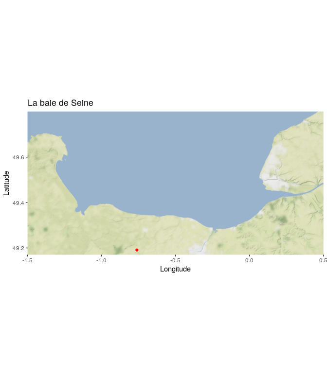

```r
    #fond<-get_stamenmap(zone,maptype="toner",zoom=9)
    mapsea<-ggmap(fond)+
        xlab("Longitude")+ylab("Latitude")+
        ggtitle("La baie de Seine")+
        geom_point(data=ecole,aes(x=x,y=y),color="red")
    print(mapsea)
```

## Activité humaines maritimes

### Carte 2

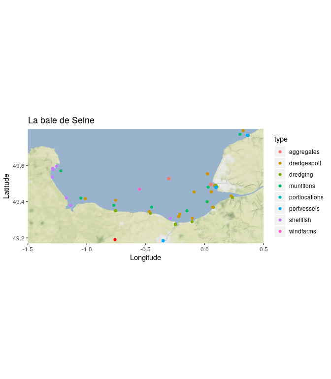

```r
    #fond<-get_stamenmap(zone,maptype="toner",zoom=9)
    mapsea2<-ggmap(fond)+
        xlab("Longitude")+ylab("Latitude")+
        ggtitle("La baie de Seine")+
        geom_point(data=ecole,aes(x=x,y=y),color="red")+
        geom_point(data=ha,aes(x=x,y=y,color=type))
    print(mapsea2)
```

### Carte 3

Densité des positions de navires en 2017 (toutes activités confondues)

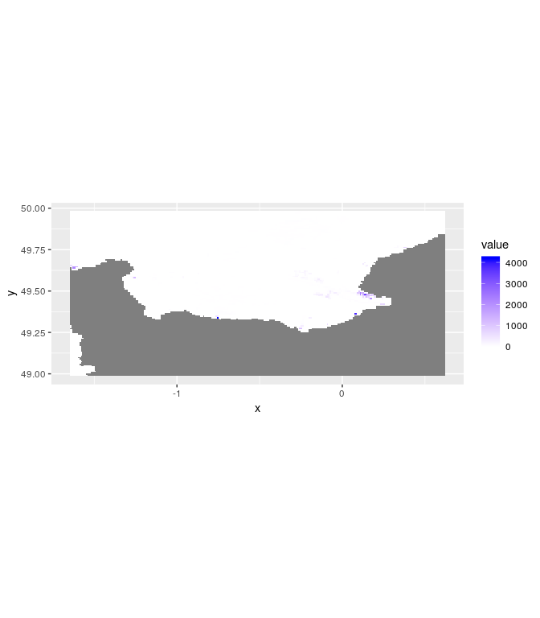

```r
    #fond<-get_stamenmap(zone,maptype="toner",zoom=9)
    #mapsea2<-ggmap(fond)+
    #   xlab("Longitude")+ylab("Latitude")+
    #   ggtitle("La baie de Seine")+
    #   geom_point(data=ecole,aes(x=x,y=y),color="red")+
    #   geom_point(data=ha,aes(x=x,y=y,color=type))
    #print(mapsea2)
    gplot(ais)+geom_tile(aes(fill=value))+
        scale_fill_gradient(low = 'white', high = 'blue') +
              coord_equal()
```

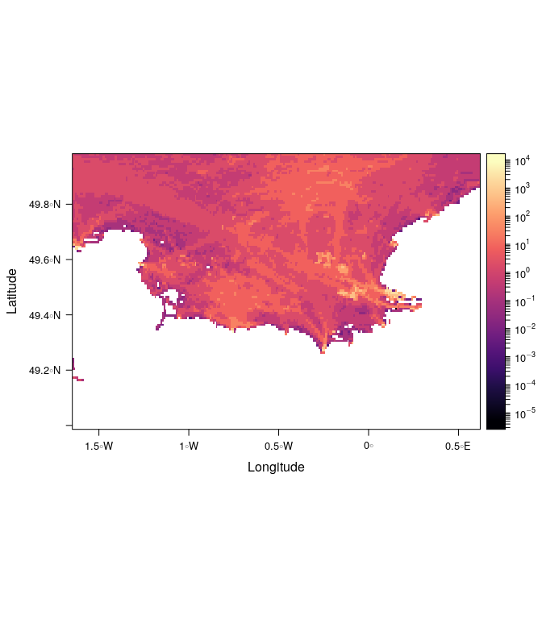

```r
      ais[ais==0]<-NA
      levelplot(ais,margin=FALSE,zscaleLog=TRUE)
```